# Instrumental Variables Analysis of Randomized Experiments with One-Sided Noncompliance

Joon-Ho Lee (joonho@berkeley.edu)

Avi Feller

Sophia Rabe-Hesketh

March 15, 2019

# 1 Introduction

# 2 The Sommer-Zeger vitamin A supplement data

We illustrate the methods presented in this document using the data from a randomized experiment to study the effect of vitamin A supplements on infant mortaility in Indonesia. The data was previously analyzed in Sommer and Zeger (1991) and is displayed in the following table:

[Table 1] Sommer-Zeger vitamin A supplement data

| Compliance Type | Assignment $Z_{i}$ | Receipt $W_{i}^{\text{obs}}$ | Survival $Y_{i}^{\text{obs}}$ | Number of units ($N$ = 23,682) |
| --- | --- | --- | --- | --- |
| never-taker | 1 | 0 | 0 | 34 |
| never-taker | 1 | 0 | 1 | 2,385 |
| complier | 1 | 1 | 0 | 12 |
| complier | 1 | 1 | 1 | 9,663 |
| complier or never-taker | 0 | 0 | 0 | 74 |
| complier or never-taker | 0 | 0 | 1 | 11,514 |
| *(not observed)* | 0 | 1 | 0 | 0 |
| *(not observed)* | 0 | 1 | 1 | 0 |

In this experiment, villages in Indonesia were randomly assigned to receive or not to receive vitamin A supplements.[^1] This *assignment* to the supplements is denoted by $Z_{i} \in \{0, 1 \}$. Some of the individuals in village assigned to the treatment group, however, chose not to take or did not get access to the vitamin supplements, while none of the individuals assigned to the control group received the supplements. The *receipt* of the supplements is considered the treatment of main interest and denoted by $W_{i}^{\text{obs}} \in \{0, 1 \}$. Noncompliance in this setting is *one-sided* because all units assigned to the control condition complied with this assignment. The binary outcome variable $Y_{i}^{\text{obs}}$ indicates survival of an infant.

The eight different combinations of three observed binary variables, $Z_{i}$, $W_{i}^{\text{obs}}$, and $Y_{i}^{\text{obs}}$, are possible in principle. Because all units assigned to the control condition complied with the assignment, however, two combinations with $Z_{i} = 0$ and $W_{i}^{\text{obs}} = 1$ were not observed in the sample. The **R** code that follows loads the dataset based on the counts of the six combinations of observed variables shown in Table. 1.

```r
# Load data: Sommer-Zeger example from Imbens and Rubin (1997)
Z <- c(rep(1, 34 + 2385 + 12 + 9663),
       rep(0, 74 + 11514))

W <- c(rep(0, 34 + 2385),
       rep(1, 12 + 9663),
       rep(0, 74 + 11514))

Y <- c(rep(0, 34),
       rep(1, 2385),
       rep(0, 12),
       rep(1, 9663),
       rep(0, 74),
       rep(1, 11514))
```

Then we collect data into a list format suitable for **Stan**.

```r
# Collect data into a list form
stan_data <- list(N = length(Y), Y = Y, Z = Z, W = W)
```

# 3 Causal estimands when confronted with one-sided noncompliance

Let us first define potential outcomes to fit the instrumental variable settings. For unit $i$, the observed treatment status $W_{i}^{\text{obs}}$ is

$$W_{i}^{\text{obs}} = W_{i}(Z_{i}) = \begin{cases}
W_{i}(0) & \text{if $Z = 0$}, \\
W_{i}(1) & \text{if $Z = 1$}.
\end{cases}$$

$W_{i}(0)$ is the treatment that unit $i$ would receive if assinged to the control ($Z_{i} = 0$). $W_{i}(1)$ is the treatment that unit $i$ would receive if assinged to the treatment ($Z_{i} = 1$). The pair of potential responses to treatment assignment for unit $i$, $(W_{i}(0), W_{i}(1))$ describes the compliance behavior. For unit $i$,

$$G_{i} = \begin{cases}
c & \text{(unit $i$ is a complier),} & \text{if $W_{i}(z) = z$, for $z = 0, 1$}, \\
n & \text{(unit $i$ is a never-taker),} & \text{if $W_{i}(z) = 0$, for $z = 0, 1$}, \\
a & \text{(unit $i$ is an always-taker),} & \text{if $W_{i}(z) = 1$, for $z = 0, 1$}, \\
d & \text{(unit $i$ is a defier),} & \text{if $W_{i}(z) = 1-z$, for $z = 0, 1$}.
\end{cases}$$

We denote the proportions of the four compliance types in the population $\pi_{g} = \Pr(G_{i} = g)$ for $g \in \{c, n, a, d\}$. The compliance behavior $G_{i}$ is a *latent pre-treatment variable* because it is not fully observed and unaffected by the treatments.

For the primary outcome, we define potential outcomes, $Y_{i}(z, w)$, the outcome observed if unit $i$ were assigned treatment $z$ and received treatment $w$. The observed outcome for unit $i$ equals

$$Y_{i}^{\text{obs}} = Y_{i}(Z_{i}, W_{i}(Z_{i})) = \begin{cases}
Y_{i}(0, 0), & \text{if $Z_{i} = 0, W_i(0) = 0$}, \\
Y_{i}(0, 1), & \text{if $Z_{i} = 0, W_i(0) = 1$}, \\
Y_{i}(1, 0), & \text{if $Z_{i} = 1, W_i(1) = 0$}, \\
Y_{i}(1, 1), & \text{if $Z_{i} = 1, W_i(1) = 1$}.
\end{cases}$$

Since both always-takers ($a$) and defiers ($d$) are not present in the one-sided noncompliance setting, we can infer the compliance type for all units with $Z_{i} = 1$. The units with ($Z_{i} = 1, W_i(1) = 0$) must be *never-takers*, and the units with ($Z_{i} = 1, W_i(1) = 1$) must be *compliers*. For units with $Z_{i} = 0$, however, we could not infer their compliance types. For a unit with ($Z_{i} = 0, W_i(0) = 1$), we know that the unit is absent because $W_{i}(0) = 0$ for all unit $i$. But for a unit with ($Z_{i} = 0, W_i(0) = 0$), we can only infer that the unit is a *complier* or a *never-taker* because the observed behavior is consistent with those of both compliance types.

Now consider the intention-to-treat (ITT) effect, the average effect of treatment assignment $Z_{i}$ on the outcome $Y_{i}$. We can decompose the super-population ITT effect in the one-sided noncompliance case into a weighted average of the subgroup effects by two compliance types (compliers and never-takers):

$$\begin{equation}
\begin{split}
\text{ITT}_{Y} &= \sum_{g \in \{c, n\}}{\mathbb{E}[Y_{i}(1, W_{i}(1))-Y_{i}(0, W_{i}(0))|G_{i} = g]} \cdot\Pr(G_{i} = g) \\
&= \mathbb{E}[Y_{i}(1, 1)-Y_{i}(0, 0)|G_i = c] \cdot \pi_c + \mathbb{E}[Y_{i}(1, 0)-Y_{i}(0, 0)|G_i = n] \cdot \pi_n \\
&= \text{ITT}_Y^{c} \cdot\pi_c + \text{ITT}_Y^n \cdot \pi_n
\end{split}
\end{equation}$$

The two subgroup effects on $Y$ by compliance type cannot be estimated directly from the observed data because the latent compliance behavior for units assigned to the control condition ($Z_{i} = 0$) cannot be inferred. But under an additional assumption, *exclusion restrictions*, we can still disentangle the ITT effects by compliance status. Exclusion restrictions capture the notion that there is no effect of assignment $Z_{i}$ on the outcome $Y_i$, in the absence of an effect of assignment $Z_i$ on the treatment received $W_i$ (Imbens and Rubin 2015). For all units with $G_i = n$ (never-takers), the exclusion restriction requires $Y_i(1, 0)$ to be equal to $Y_i(0, 0)$. In other words, the potential outcomes are unaffected by the assignment $Z_i$ for never-takers who would not receive the treatments even if assigned to take them.

Because the super-population average ITT effect for never-takers ($\text{ITT}_Y^n$) is zero under the exclusion restriction, the ITT effect on the primary outcome $\text{ITT}_Y$ can be simplified to

$$\begin{equation}
\begin{split}
\text{ITT}_{Y} &= \mathbb{E}[Y_{i}(1, 1)-Y_{i}(0, 0)|G_i = c] \cdot \pi_c \\
&= \mathbb{E}[Y_{i}(1)-Y_{i}(0)|G_i = c] \cdot \pi_c \\
&= \text{ITT}_Y^{c} \cdot\pi_c.
\end{split}
\end{equation}$$

Note that we are dropping the $z$ argument in the potential outcomes because $z$ is always equal to $w$ for compliers. The estimand of our primary interest, the complier average causal effect ($\text{ITT}_Y^{c}$, CACE), is now the ITT effect of $Z_i$ on the outcome $Y_i$ ($\text{ITT}_{Y}$) divided by the proportion of compliers in the populaion ($\pi_c$). This simple moment-based instrumental variable estimator for CACE can be estimated easily with two unbiased estimators, the sample average difference in treatment receipt status by assignment status ($\widehat{\text{ITT}}_{W}$) and the difference in outcome by assignment status ($\widehat{\text{ITT}}_{Y}$). See the chapter 23 of Imbens and Rubin (2015) for details.

# 4 Model-based analysis in randomized experiments with one-sided noncompliance

The moment-based estimator is based on differences in sample averages for different groups, thereby ignoring individual-level information about compliance status. As an alternative to the standard ratio estimator, Imbens and Rubin (1997) developed a model-based, or simulation approach for estimating causal effects in randomized experiements with noncompliance, which focuses on each individual’s compliance status.

The model-based estimation strategy has several advantages over the moment-based approach. First, it provides a principled framework to assess the effects of the various restrictions on the joint distribution of the observed variables (Imbens and Rubin 2015). In our one-sided noncompliance example, the model-based approach allows us to assess the sensitivity of the CACE estimate to the exclusion restriction for never-takers, which will be discussed in more deail in this document. Second, the model-based approach provides more precise estimates if the proposed parametric model is approximately correct, particularly when there is a small sample size or proportion of compliers (Page et al. 2015). Lastly, it allows for a flexible way to extend the model to settings with covariates or complex compliance status (e.g., Feller et al. 2016).

In this section we illustrate two models and associated **Stan** programs for estimating CACE with one-sided noncompliance, with and without the exclusion restriction for never-takers. See the chapter 25 of Imbens and Rubin (2015) for the detailed description of the model-based estimation strategy.

## 4.1 **Stan** model *with* exclusion restriction for never-takers

As data inputs for the model, we first code three observed binary variables ($Z_{i}$, $W_{i}^{\text{obs}}$, and $Y_{i}^{\text{obs}}$) and the number of units in the sample ($N$):

```
data {
  int<lower=1> N;              // Sample size N
  int<lower=0,upper=1> Z[N];   // Treatment assigned Z
  int<lower=0,upper=1> W[N];   // Treatment received W
  int<lower=0,upper=1> Y[N];   // Outcome Y
}
```

Next, we define a full parameter vector $\theta$ for the model. With no defiers and always-takers in the one-sided noncompliance setting ($\pi_{a}=\pi_{d}=0$), we need to define only the population probability of a unit being a complier $\pi_{c} = \Pr(G_i = c|Z_i)$ because the probability of being a never-taker $\pi_{n}$ is $1-\pi_{c}$.

With binary outcomes, we assume that the outcome distribution for each compliance type follows a binomial distribution with the probability of survival of an infant for compliance type $g \in \{c, n\}$ when assigned $z \in \{0, 1\}$, which we denote as $\eta_{gz}$. There are four relevant scalar parameters for the outcome distributions: $\eta_{c0}$, $\eta_{c1}$, $\eta_{n0}$, and $\eta_{n1}$. Due to the exclusion restriction, however, we assume that the model parameters are the same under $z = 0$ and $z = 1$ for never-takers (i.e., $\eta_{n0} = \eta_{n1} = \eta_{n}$) because the potential outcomes are assumed to be unaffected by the treatment assignment $Z_i$ for them. Thus, the complete parameter vector $\theta$ consists of four parameters, $(\pi_{c}, \eta_{c0}, \eta_{c1}, \eta_{n})$ and coded as follows in the **Stan** program:

```
parameters {
  // Population probability of being a complier
  real<lower=0,upper=1> pi_c;

  // Probabilities for the binomial outcome distributions
  real<lower=0,upper=1> eta_c0;
  real<lower=0,upper=1> eta_c1;
  real<lower=0,upper=1> eta_n;
}
```

The `model` block in the **Stan** program defines prior distributions and the likelihood. The first portion of the `model` section includes prior distributions for the parameters. By not specifying a prior for $\pi_c$, **Stan** automatically provides $\pi_c$ an implicit uniform prior, $\pi_c \sim \text{Unif}(0, 1)$. Conjugate Beta priors for the binomial outcome distributions with $\alpha = \beta = 2$ are used for $(\eta_{c0}, \eta_{c1}, \eta_{n})$ as in Imbens and Rubin (1997).

The crux of the model-based estimation is the use of a full likelihood incorporating the individual-level information about compliance status. To define the actual observed data likelihood function for parameters, we first partition the set of $N$ units into the subsets of units representing each pattern of missing and observed data. In the one-sided noncompliance setting described above, the three possible values for $(Z_i, W_i^{\text{obs}})$ are $(0, 0)$, $(1, 0)$, and $(1, 1)$. We denote the mutually exclusive and collectively exhaustive subsets by $\mathcal{S}(0, 0)$, $\mathcal{S}(1, 0)$, and $\mathcal{S}(1, 1)$.

For the set $\mathcal{S}(1, 1)$, we can infer that units with these pattern of observed compliance behavior are *compliers* because there are no always-takers. Likewise, it is easy to infer that units for the set $\mathcal{S}(1, 0)$ are *never-takers* under the monotonicity assumption. For these two sets, the likelihood contribution from the $i$th such unit is proportional to the conditional distribution of observed outcomes $f(Y_{i}^{\text{obs}}|G_i = g, Z_i = z, \eta_{gz})$ with weights given by the compliance type probability $\Pr(G_i = g | Z_{i} = z)$.

But for the set $\mathcal{S}(0, 0)$, we cannot surely infer the compliance type of the units because both *compliers* and *never-takers* receive the control treatment after being assigned to the control group. Thus, the observed outcome $Y_{i}^{\text{obs}}$ can either be from two different outcome distributions, $f(Y_{i}^{\text{obs}}|G_i = c, Z_i = 0, \eta_{c0})$ or $f(Y_{i}^{\text{obs}}|G_i = n, Z_i = 0, \eta_{n})$. Thus, we model the likelihood contribution for the $i$th unit in the set $\mathcal{S}(0, 0)$ as a mixture of the two outcome distributions, within which $Y_{i}^{\text{obs}}$ is drawn from the distribution for compliers with probability of $\Pr(G_i = c | Z_{i} = 0)$, and $Y_{i}^{\text{obs}}$ is drawn from the distribution for never-takers with probability of $\Pr(G_i = n | Z_{i} = 0)$.

Given these specification for the outcome distributions and the the probabilities of compliance type for the three subsets, we can write the full likelihood function in terms of the observed data as:

$$\begin{equation}
\begin{split}
\Pr(\mathrm{W}^{\text{obs}}, \mathrm{Y}^{\text{obs}} | \mathrm{Z}^{\text{obs}}, \theta) &= \prod_{i \in \mathcal{S}(1, 1)}{\Pr(G_i = c|Z_{i} = 1) \cdot f(Y_{i}^{\text{obs}}|G_i = c, Z_i = 1, \eta_{c1})} \times \\
& \prod_{i \in \mathcal{S}(1, 0)}{\Pr(G_i = n | Z_{i} = 1) \cdot f(Y_{i}^{\text{obs}} | G_i = n, Z_i = 1, \eta_{n})} \times \\
& \prod_{i \in \mathcal{S}(0, 0)}{\{\Pr(G_i = c | Z_{i} = 0) \cdot f(Y_{i}^{\text{obs}} | G_i = c, Z_i = 0, \eta_{c0})} +\Pr(G_i = n | Z_{i} = 0) \cdot f(Y_{i}^{\text{obs}} | G_i = n, Z_i = 0, \eta_{n}) \}.
\end{split}
\end{equation}$$

Since there is no built-in **Stan** function that address the specific mixture structure of this likelihood function, we construct the likelihood function more directly in the `model` block. We work with the *log-likelihood* because **Stan**’s execution is based on the evaluation of a log probability function for a given set of parameters. By taking the natural logarithm of the likelihood function defined above, the log of a product of terms inside the likelihood function becomes a sum of the log of the terms, which lead to the following **Stan** program:

```
model {
  // Prior for Complier probability
  // implicit prior: pi_c ~ Unif(0, 1)

  // Priors for outcome model parameters
  eta_c0 ~ beta(2, 2);
  eta_c1 ~ beta(2, 2);
  eta_n ~ beta(2, 2);

  // Likelihood
  for(n in 1:N){

    // Complier (assigned to treatment)
    if(Z[n] == 1 && W[n] == 1){
      target += log(pi_c) + bernoulli_lpmf(Y[n] | eta_c1) ;
    }

    // Never-taker (assigned to treatment)
    else if(Z[n] == 1 && W[n] == 0){
      target +=  log(1 - pi_c) + bernoulli_lpmf(Y[n] | eta_n);
    }

    // Complier or Never-taker (assigned to control)
    else if(Z[n] == 0 && W[n] == 0){
      target += log_sum_exp(
        log(1 - pi_c) + bernoulli_lpmf(Y[n] | eta_n),  // Never-taker
        log(pi_c) + bernoulli_lpmf(Y[n] | eta_c0));    // Complier
    }
  }
}
```

Note that the likelihood function is expressed as an increment to the log probability function using `target +=` statement. The model accumulates the log contributions from the mixture components within each of three observed data subsets, $\mathcal{S}(1, 1)$, $\mathcal{S}(1, 0)$, and $\mathcal{S}(0, 0)$. For a never-takers assigned to treatment, for example, two components are calculated and added as log contributions to the total log probability: (1) the log of the probability of being a never-taker given treatment assignment (`log(1 - pi_c)`) and (2) the log Bernoulli probability mass evaluated at the point `Y[n]` given the probability of survival of an infant for never-takers (`bernoulli_lpmf(Y[n] | eta_n)`).

For the set $\mathcal{S}(0, 0)$, the log sum of exponentials function (`log_sum_exp()`) is used to define mixtures on the log scale. The `log_sum_exp(a, b)` function is equivalent to `log(exp(a) + exp(b))` but is more useful to stablize the numerical arithmetic (See the [Chapter 5 of Stan User’s Guide](https://mc-stan.org/docs/2_22/stan-users-guide/summing-out-the-responsibility-parameter.html)). Using this function, we calculate the log-likelihood contributions for units in the subset $\mathcal{S}(0, 0)$ which are drawn from a mixture of outcome distributions of two compliance types, compliers and never-takers.

The estimand of primary interest is the super-population complier average causal effect (CACE) $\eta_{c1}-\eta_{c0}$. We can include the optional `transformed parameters` block to generate the posterior distribution for the CACE defined as a function of the declared parameters:

```
transformed parameters {
  // Superpopulation complier average causal effect (CACE)
  // in per-1000 units
  real CACE;
  CACE = (eta_c1 - eta_c0)*10^3;
}
```

We changed the scale of the CACE estimates by simply multiplying $10^{3}$ to the original estimates. The resulting CACE estimate thus means the causal effect of vitamin A supplements on infant mortaility in per 1,000 individual, for *compliers* in the population.

The code blocks specified in this section are combined in the **Stan** program **Model_01_CACE_with_Exclusion_Restriction.stan**, which is then fit to the Sommer-Zeger vitamin A supplement data:

```r
# Compile and run the stan model
stan_fit_ER <- stan( file = "Model_01_CACE_with_Exclusion_Restriction.stan",
                     data = stan_data,
                     iter = 1000, chains = 4)
```

The posterior means and standard deviations of the parameters can be displayed as follows:

```r
print(stan_fit_ER, probs = c(0.05, 0.5, 0.95), digits = 3)
```

```
## Inference for Stan model: Model_01_CACE_with_Exclusion_Restriction.
## 4 chains, each with iter=1000; warmup=500; thin=1;
## post-warmup draws per chain=500, total post-warmup draws=2000.
##
##             mean se_mean    sd        5%       50%       95% n_eff  Rhat
## pi_c       0.800   0.000 0.004     0.794     0.800     0.806  2141 0.999
## eta_c0     0.995   0.000 0.001     0.993     0.995     0.997  1632 1.000
## eta_c1     0.999   0.000 0.000     0.998     0.999     0.999  1875 1.000
## eta_n      0.986   0.000 0.002     0.982     0.986     0.989  1656 0.999
## CACE       3.221   0.028 1.176     1.318     3.208     5.235  1745 1.000
## lp__   -6807.344   0.050 1.393 -6810.140 -6807.036 -6805.678   764 0.999
##
## Samples were drawn using NUTS(diag_e) at Wed Mar 18 00:37:30 2020.
## For each parameter, n_eff is a crude measure of effective sample size,
## and Rhat is the potential scale reduction factor on split chains (at
## convergence, Rhat=1).
```

Before interpreting the results, it is necessary to check that the chains have converged for each parameter. The $\hat{R}$ statistics shown in the rightmost column of the model summary are all less than 1.1. Also the effective sample size estimates are sufficient for inference. According to the Gelman, Rubin, and others (1992) criterior for convergence, it seems that **Stan** has produced an adequate approximation of the posterior.

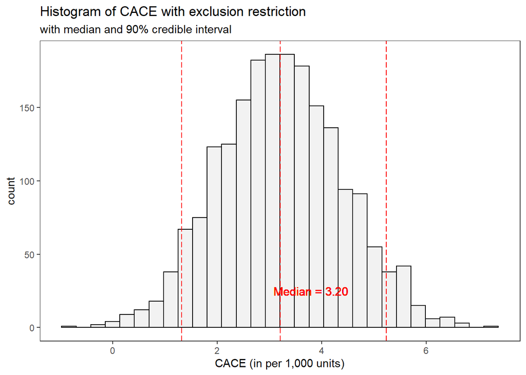

```r
# Plot the histogram of CACE with exclusion restriction
CACE <- rstan::extract(stan_fit_ER, pars = "CACE")$CACE
df_CACE <- data.frame(CACE); names(df_CACE) <- c("CACE")

ggplot(data = df_CACE, aes(x = CACE)) +
  geom_histogram(color = "black", fill = "gray95") +
  geom_vline(xintercept = c(quantile(CACE, probs = c(0.05, 0.50, 0.95))),
             color = "red", linetype = "longdash") +
  geom_text(aes(3.8, 25), label = "Median = 3.20", color = "red", size = 4) +
  scale_x_continuous("CACE (in per 1,000 units)",
                     breaks = seq(from = -4, to = 10, by = 2)) +
  labs(title = "Histogram of CACE with exclusion restriction",
       subtitle = "with median and 90% credible interval") +
  theme_bw() + theme(panel.grid = element_blank())
```

## 4.2 **Stan** model *without* exclusion restriction for never-takers

In this section we assess the sensitivity of the CACE estimate to the exclusion restriction for never-takers. Without the exclusion restriction, the potential outcomes for never-takers are assumed to be affected by the treatment assignment $Z_i$. Hence we assume that the outcome model parameters under different treatment assignment, $\eta_{n0}$ and $\eta_{n1}$, are not the same for never-takers. Now the complete parameter vector is $\theta = (\pi_{c}, \eta_{c0}, \eta_{c1}, \eta_{n0}, \eta_{n1})$ and coded as follows in the **Stan** program:

```
parameters {
  // Population probability of being a complier
  real<lower=0,upper=1> pi_c;

  // Probabilities for the binomial outcome distributions
  real<lower=0,upper=1> eta_c0;
  real<lower=0,upper=1> eta_c1;
  real<lower=0,upper=1> eta_n0;
  real<lower=0,upper=1> eta_n1;
}
```

The `model` block shares the almost the same prior distributions and the likelihood with that of the model specified in the previous section. We use the identical conjugate Beta priors for the binomial outcome distributions with $\alpha = \beta = 2$ for $(\eta_{c0}, \eta_{c1}, \eta_{n0}, \eta_{n1})$. The full likelihood function has the identical mixture structure defined across three data subsets $\mathcal{S}(0, 0)$, $\mathcal{S}(1, 0)$, and $\mathcal{S}(1, 1)$. The only difference is the parameterization of the outcome distributions for never-takers. Instead of using a common parameter $\eta_{n}$ for modeling the conditional distributions of observed outcomes regardless of treatment assignment, we use separate outcome model parameters for $f(Y_{i}^{\text{obs}}|G_i = n, Z_i = 0, \eta_{n0})$ and $f(Y_{i}^{\text{obs}}|G_i = n, Z_i = 1, \eta_{n1})$:

```
model {
  // Prior for Complier probability
  // implicit prior: pi_c ~ Unif(0, 1)

  // Priors for outcome model parameters
  eta_c0 ~ beta(2, 2);
  eta_c1 ~ beta(2, 2);
  eta_n0 ~ beta(2, 2);
  eta_n1 ~ beta(2, 2);

  // Likelihood
  for(n in 1:N){

    // Complier (assigned to treatment)
    if(Z[n] == 1 && W[n] == 1){
      target += log(pi_c) + bernoulli_lpmf(Y[n] | eta_c1) ;
    }

    // Never-taker (assigned to treatment)
    else if(Z[n] == 1 && W[n] == 0){
      target +=  log(1 - pi_c) + bernoulli_lpmf(Y[n] | eta_n1);
    }

    // Complier or Never-taker (assigned to control)
    else if(Z[n] == 0 && W[n] == 0){
      target += log_sum_exp(
        log(1 - pi_c) + bernoulli_lpmf(Y[n] | eta_n0),  // Never-taker
        log(pi_c) + bernoulli_lpmf(Y[n] | eta_c0));     // Complier
    }
  }
}
```

In addition to the main causal estimand, the super-population complier average causal effect (CACE, $\eta_{c1} - \eta_{c0}$), we can now define the super-population average causal effect of treatment assignment on outcome for never-takers (NACE, $\eta_{n1} - \eta_{n0}$) in the `transformed parameters` block:

```
transformed parameters {
  // Super-population average causal effects
  real CACE;
  real NACE;
  CACE = (eta_c1 - eta_c0)*10^3;
  NACE = (eta_n1 - eta_n0)*10^3;
}
```

The **Stan** program **Model_02_CACE_without_Exclusion_Restriction.stan** is then fit to the example data:

```r
# Compile and run the stan model
stan_fit_noER <- stan( file = "Model_02_CACE_without_Exclusion_Restriction.stan",
                       data = stan_data,
                       iter = 1000, chains = 4)
```

The CACE and NACE estimates without assuming exclusion restriction for never-takers are displayed in tabular form as follows. The $\hat{R}$ statistics and the effective sample size estimates suggest that chains have converged for each parameter:

```r
# Print output
print(stan_fit_noER, probs = c(0.05, 0.5, 0.95), digits = 3)
```

```
## Inference for Stan model: Model_02_CACE_without_Exclusion_Restriction.
## 4 chains, each with iter=1000; warmup=500; thin=1;
## post-warmup draws per chain=500, total post-warmup draws=2000.
##
##             mean se_mean    sd        5%       50%       95% n_eff  Rhat
## pi_c       0.800   0.000 0.004     0.794     0.800     0.806  2320 1.000
## eta_c0     0.996   0.000 0.002     0.993     0.996     0.999  1393 1.002
## eta_c1     0.999   0.000 0.000     0.998     0.999     0.999  2186 0.999
## eta_n0     0.984   0.000 0.008     0.970     0.984     0.996  1401 1.001
## eta_n1     0.985   0.000 0.002     0.981     0.985     0.989  2110 0.999
## CACE       2.826   0.053 1.971    -0.316     2.810     6.041  1375 1.001
## NACE       1.580   0.214 8.187   -11.208     1.353    15.319  1461 1.001
## lp__   -6816.351   0.048 1.549 -6819.202 -6816.093 -6814.414  1041 1.002
##
## Samples were drawn using NUTS(diag_e) at Wed Mar 18 00:42:28 2020.
## For each parameter, n_eff is a crude measure of effective sample size,
## and Rhat is the potential scale reduction factor on split chains (at
## convergence, Rhat=1).
```

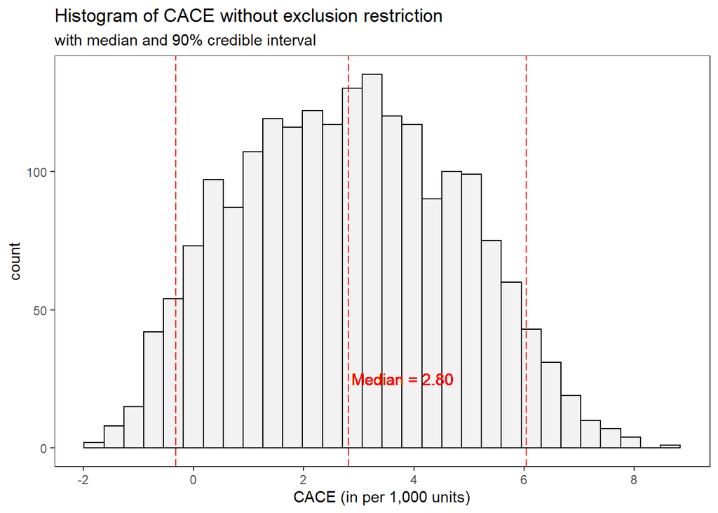

```r
# Plot the histogram of CACE with exclusion restriction
CACE <- rstan::extract(stan_fit_noER, pars = "CACE")$CACE
df_CACE <- data.frame(CACE); names(df_CACE) <- c("CACE")

ggplot(data = df_CACE, aes(x = CACE)) +
  geom_histogram(color = "black", fill = "gray95") +
  geom_vline(xintercept = c(quantile(CACE, probs = c(0.05, 0.50, 0.95))),
             color = "red", linetype = "longdash") +
  geom_text(aes(3.8, 25), label = "Median = 2.80", color = "red", size = 4) +
  scale_x_continuous("CACE (in per 1,000 units)",
                     breaks = seq(from = -4, to = 10, by = 2)) +
  labs(title = "Histogram of CACE without exclusion restriction",
       subtitle = "with median and 90% credible interval") +
  theme_bw() + theme(panel.grid = element_blank())
```

We also replicates the Figure 2 of Imbens and Rubin (1997), which represents the posterior distribution for NACE:

[figure not shown]

```r
# Plot the histogram of CACE with exclusion restriction
NACE <- rstan::extract(stan_fit_noER, pars = "NACE")$NACE
df_NACE <- data.frame(NACE); names(df_NACE) <- c("NACE")

ggplot(data = df_NACE, aes(x = NACE)) +
  geom_histogram(color = "black", fill = "gray95") +
  geom_vline(xintercept = c(quantile(NACE, probs = c(0.05, 0.50, 0.95))),
             color = "red", linetype = "longdash") +
  geom_text(aes(3.8, 25), label = "Median = 1.90", color = "red", size = 4) +
  scale_x_continuous("NACE (in per 1,000 units)",
                     breaks = seq(from = -30, to = 30, by = 2)) +
  labs(title = "Histogram of NACE without exclusion restriction",
       subtitle = "with median and 90% credible interval") +
  theme_bw() + theme(panel.grid = element_blank())
```

Under the exclusion restriction, the NACE is forced to be 0 because $\eta_{n0} = \eta_{n1}$. Without the exclusion restriction, however, the NACE has a posterior distribution, which turns out to be centered around 0, lending credibility to the exclusion restriction (Imbens and Rubin 1997).

Next, we plot the joint posterior distribution of CACE and NACE without exclusion restriction, which replicates the Figure 4 of (Imbens and Rubin 1997):

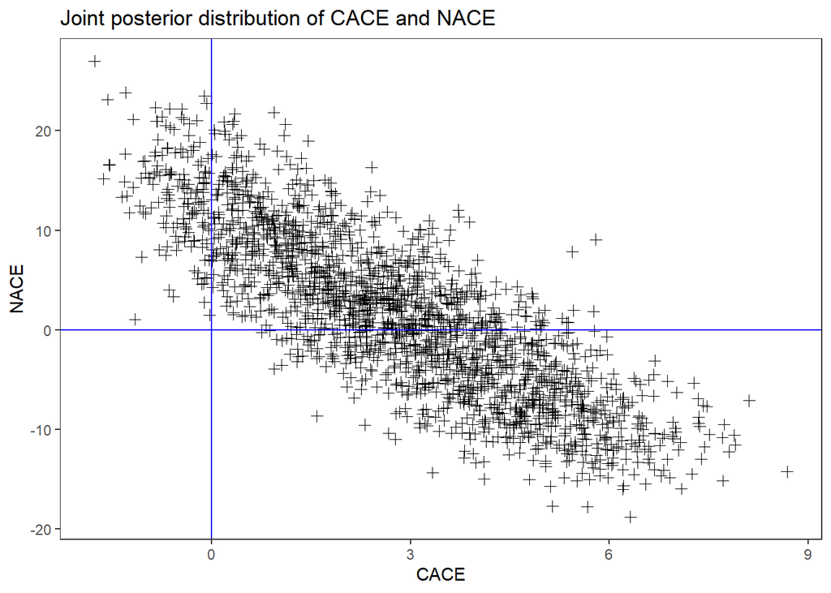

```r
# Plot joint posterior distribution of CACE and NACE
ggplot(cbind.data.frame(df_CACE, df_NACE), aes(x = CACE, y = NACE)) +
  geom_point(size = 2, shape = 3) +
  geom_vline(xintercept = 0, color = "blue") +
  geom_hline(yintercept = 0, color = "blue") +
  labs(title = "Joint posterior distribution of CACE and NACE") +
  theme_bw() + theme(panel.grid = element_blank())
```

From the plot, we must believe that NACE has a strong *positive* effects in order to believe that CACE has a *negative* effect. Since this combination of hypotheses does not seem plausible, one can be confident that receipt of treatment has a positive effect on outcome, even without making the exclusion restriction for never-takers (Imbens and Rubin 1997).

# References

Feller, Avi, Todd Grindal, Luke Miratrix, Lindsay C Page, and others. 2016. “Compared to What? Variation in the Impacts of Early Childhood Education by Alternative Care Type.” *The Annals of Applied Statistics* 10 (3): 1245–85.

Gelman, Andrew, Donald B Rubin, and others. 1992. “Inference from Iterative Simulation Using Multiple Sequences.” *Statistical Science* 7 (4): 457–72.

Imbens, Guido W, and Donald B Rubin. 1997. “Bayesian Inference for Causal Effects in Randomized Experiments with Noncompliance.” *The Annals of Statistics*, 305–27.

———. 2015. *Causal Inference in Statistics, Social, and Biomedical Sciences*. Cambridge University Press.

Page, Lindsay C, Avi Feller, Todd Grindal, Luke Miratrix, and Marie-Andree Somers. 2015. “Principal Stratification: A Tool for Understanding Variation in Program Effects Across Endogenous Subgroups.” *American Journal of Evaluation* 36 (4): 514–31.

Sommer, Alfred, and Scott L Zeger. 1991. “On Estimating Efficacy from Clinical Trials.” *Statistics in Medicine* 10 (1): 45–52.

[^1]: This is the setting where treatment is randomized at the group (village) level, but noncompliance occurs at the individual level. Imbens and Rubin (1997) mention that indicators for the village are not available to authors, which prevents them to take into account the clustering resulting from the village-level randomization.